# Handling data in RStudio

Author

Carlo Zampieri

Published

May 28, 2026

This tutorial gives you an example on how you can access and extract data from the files you download from the CMEMS. All the data mentioned here are available in the [*examples_data*](https://github.com/czampy/copernicus_ws/tree/main/examples_data) folder of the GitHub repository.

## The NetCDF-4 format

The files you download from Copernicus are often in the format `NetCDF-4`. As described its official [documentation](https://docs.unidata.ucar.edu/netcdf-c/current/index.html), *“NetCDF is a set of software libraries and self-describing, machine-independent data formats that support the creation, access, and sharing of array-oriented scientific data”*. Imagine `NetCDF-4` as a multidimensional array (usually 3D) of data. In the case of the geo-referenced data you download from Copernicus, the array has 3 dimensions: two for longitude and latitude, and one for time or depth, or the combination of them. Common office software don’t work with this format, but programming (R, Python, Matlab, etc.) and GIS (QGIS or ArcGIS) software allow to access and handle `NetCDF-4` with great potential. Let’s see some example in RStudio to understand it better!

## Useful packages

To work with NetCDF files we need to load some packages which contain useful functions:

```r
library(tidyr)
library(dplyr)
library(terra)
library(sf)
```

**Note**

See the pre-workshop slides to know how to install the required packages.

## Load and explore CMEMS data

For this tutorial we will use data that were downloaded form CMEMS. Particularly, we will use monthly data of surface temperature, salinity and concentration of chlorophyll available in the products [Mediterranean Sea Physics Reanalysis](https://doi.org/10.48670/mds-00375) and [Mediterranean Sea Biogeochemistry Reanalysis](https://doi.org/10.48670/mds-00374).

We use the function `list.files()`[^1] to list the files in the folder *examples_data*, which present the word *cmems* in their names:

```r
cmems_files <- list.files("../examples_data/",full.names = T,pattern = "cmems")
cmems_files
```

```
[1] "../examples_data/cmems_mod_med_bgc-plankton_my_4.2km_P1M-m_1779453504295.nc"
[2] "../examples_data/cmems_mod_med_phy-sal_my_4.2km_P1M-m_1779453175516.nc"
[3] "../examples_data/cmems_mod_med_phy-temp_my_4.2km_P1M-m_1779453289660.nc"
```

There are 3 files, one for each of the variables. We use the function `rast` from the `terra` package to load the files in RStudio as one object of class `SpatRaster`:

```r
cmems_data <- rast(cmems_files)
cmems_data
```

```
class       : SpatRaster
dimensions  : 108, 180, 12  (nrow, ncol, nlyr)
resolution  : 0.04166668, 0.04166665  (x, y)
extent      : 11.47917, 18.97917, 41.5, 46  (xmin, xmax, ymin, ymax)
coord. ref. : lon/lat WGS 84 (CRS84) (OGC:CRS84)
sources     : cmems_mod_med_bgc-plankton_my_4.2km_P1M-m_1779453504295.nc  (4 layers)
              cmems_mod_med_phy-sal_my_4.2km_P1M-m_1779453175516.nc  (4 layers)
              cmems_mod_med_phy-temp_my_4.2km_P1M-m_1779453289660.nc  (4 layers)
varnames    : chl (Concentration of Chlorophyll in sea water)
              so (Salinity)
              thetao (Potential temperature)
names       : chl_d~366_1, chl_d~366_2, chl_d~366_3, chl_d~366_4, so_de~366_1, so_de~366_2, ...
unit        :      mg m-3,      mg m-3,      mg m-3,      mg m-3,       0.001,       0.001, ...
time        : 2020-06-01 to 2020-09-01 UTC
```

```r
varnames(cmems_data)
```

```
[1] "chl"    "so"     "thetao"
```

```r
time(cmems_data)
```

```
 [1] "2020-06-01 UTC" "2020-07-01 UTC" "2020-08-01 UTC" "2020-09-01 UTC"
 [5] "2020-06-01 UTC" "2020-07-01 UTC" "2020-08-01 UTC" "2020-09-01 UTC"
 [9] "2020-06-01 UTC" "2020-07-01 UTC" "2020-08-01 UTC" "2020-09-01 UTC"
```

```r
names(cmems_data)
```

```
 [1] "chl_depth=1.0182366_1"    "chl_depth=1.0182366_2"
 [3] "chl_depth=1.0182366_3"    "chl_depth=1.0182366_4"
 [5] "so_depth=1.0182366_1"     "so_depth=1.0182366_2"
 [7] "so_depth=1.0182366_3"     "so_depth=1.0182366_4"
 [9] "thetao_depth=1.0182366_1" "thetao_depth=1.0182366_2"
[11] "thetao_depth=1.0182366_3" "thetao_depth=1.0182366_4"
```

Note that the layers names include the variable name, the depth slice, and the layer number (for example the first, the second, the third or the forth layer of the file). Layers names can be changed in order to be more informative, for example to show just the variable name and the time slice, as shown in the following box:

```r
names(cmems_data) <- paste(gsub("_.*","",names(cmems_data)),time(cmems_data),sep = '_')
names(cmems_data)
```

```
 [1] "chl_2020-06-01"    "chl_2020-07-01"    "chl_2020-08-01"
 [4] "chl_2020-09-01"    "so_2020-06-01"     "so_2020-07-01"
 [7] "so_2020-08-01"     "so_2020-09-01"     "thetao_2020-06-01"
[10] "thetao_2020-07-01" "thetao_2020-08-01" "thetao_2020-09-01"
```

We can also explore the data by plotting them with the function `plot()`:

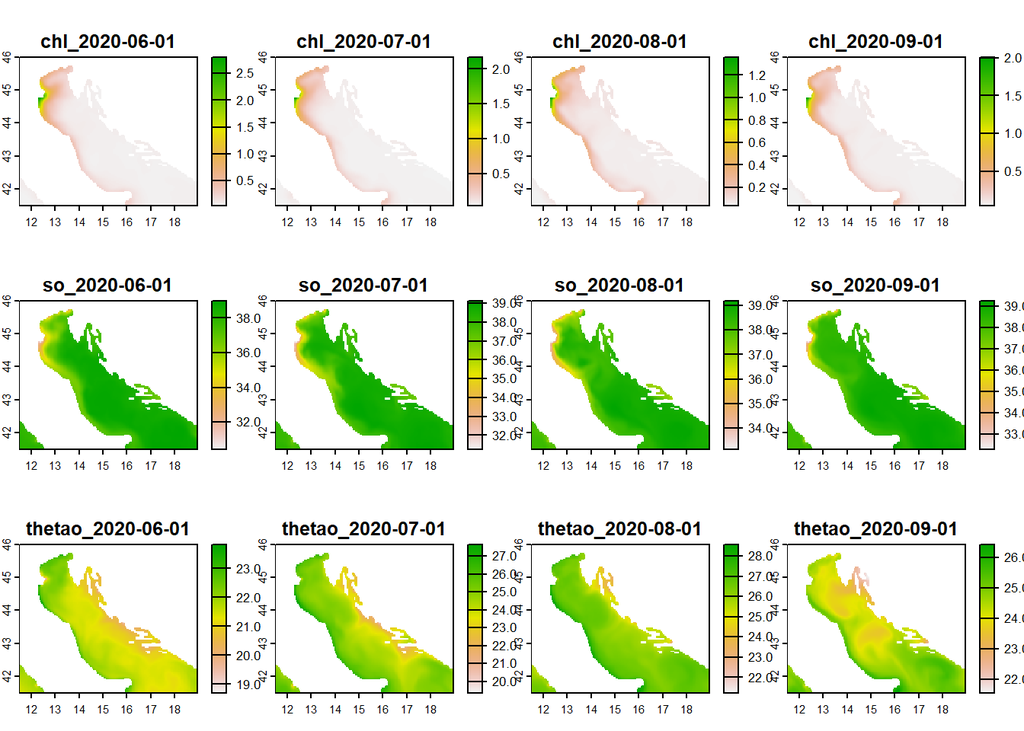

```r
plot(cmems_data,main=names(cmems_data))
```

## Extract data by location and time

It is common to want to extract the values for specific locations and times or time periods. The `sample.csv` file in the *example_data* folder reports a table with date and coordinates of 6 sampling events carried out in the Adriatic Sea. We use the functions `read.csv()`[^2] and `head()` to load and explore the file, respectively:

```r
sample_xy <- read.csv("../examples_data/sample.csv",dec = ".",sep = ";")
head(sample_xy)
```

```
        Date      Lat      Lon
1 14/06/2020 44.99806 12.62444
2 20/06/2020 44.17603 13.12070
3 12/07/2020 45.60828 13.45355
4 26/07/2020 44.12694 12.89472
5 01/08/2020 44.00707 13.19172
6 16/08/2020 45.37222 13.13417
```

We can even plot the points over one the raster layers:

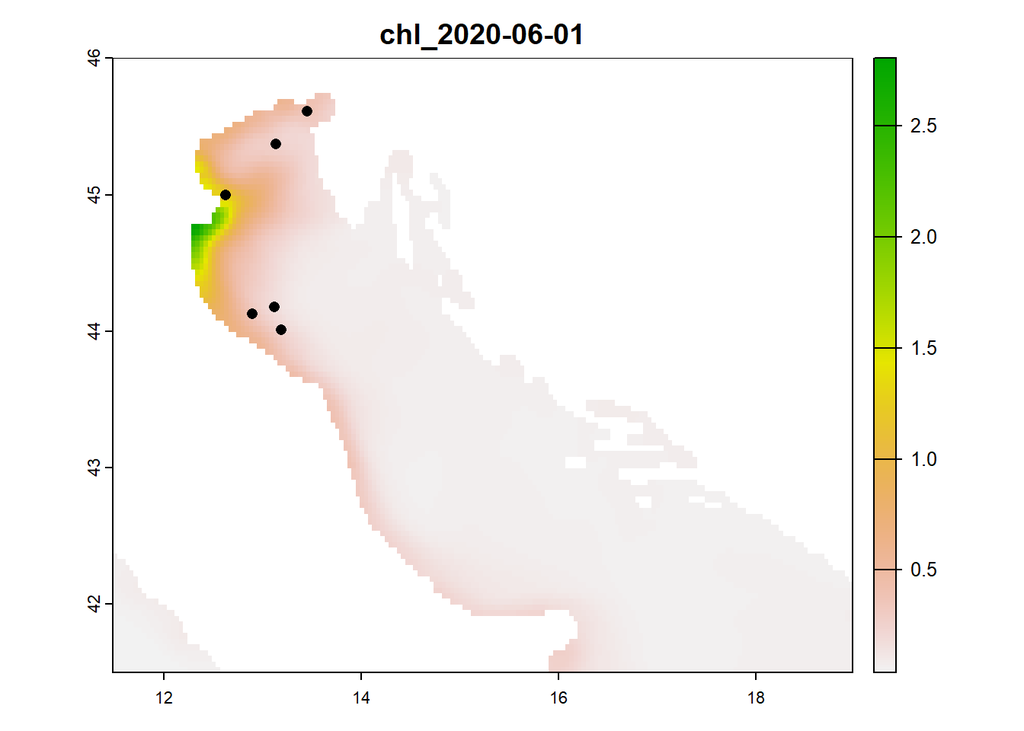

```r
plot(cmems_data,1,main=names(cmems_data)[1])
points(sample_xy$Lon,sample_xy$Lat,pch=16,add=TRUE)
```

The `extract()` function from the `terra` package allows to search into a raster the values of specific locations (expressed in coordinates):

```r
extract(cmems_data,sample_xy[,c(3,2)])
```

```
  ID chl_2020-06-01 chl_2020-07-01 chl_2020-08-01 chl_2020-09-01 so_2020-06-01
1  1      1.2820040      0.9438344     0.57200551      0.6506224      34.56345
2  2      0.1679658      0.1344204     0.09711253      0.1131086      37.40252
3  3      0.3618798      0.3583637     0.26925361      0.2826284      36.02984
4  4      0.3590689      0.3323720     0.20135331      0.2867707      35.64000
5  5      0.2213878      0.1680759     0.11020434      0.1612557      36.39019
6  6      0.2630654      0.2270411     0.16424924      0.2402323      36.81427
  so_2020-07-01 so_2020-08-01 so_2020-09-01 thetao_2020-06-01 thetao_2020-07-01
1      34.97503      36.02798      36.05122          20.55059          24.77812
2      37.15281      37.98838      38.43053          21.89000          25.11073
3      36.84688      36.82774      37.16343          22.46881          25.23509
4      35.96719      36.87722      37.10883          21.98404          25.62411
5      36.35640      37.38656      37.89978          21.80790          25.38047
6      37.59502      37.47272      38.34882          22.23587          24.96291
  thetao_2020-08-01 thetao_2020-09-01
1          26.26455          24.39301
2          26.61039          24.03092
3          26.51292          24.20549
4          26.90511          24.51233
5          26.78592          24.25875
6          26.35469          24.12581
```

The function produced a table with the values for each point (rows) from each layer of the `cmems_data` object (columns). We can transpose the table to have a column for the layer name and one for the extracted values by using the function `pivot_longer()` (from the `tidyr` package). We concatenate the executions by using the pipe operator `%>%` implemented in the `dplyr` package:

```r
extract(cmems_data,sample_xy[,c(3,2)]) %>%
  pivot_longer(cols = -1,names_to = "layer",values_to = "value")
```

```
# A tibble: 72 × 3
      ID layer              value
   <dbl> <chr>              <dbl>
 1     1 chl_2020-06-01     1.28
 2     1 chl_2020-07-01     0.944
 3     1 chl_2020-08-01     0.572
 4     1 chl_2020-09-01     0.651
 5     1 so_2020-06-01     34.6
 6     1 so_2020-07-01     35.0
 7     1 so_2020-08-01     36.0
 8     1 so_2020-09-01     36.1
 9     1 thetao_2020-06-01 20.6
10     1 thetao_2020-07-01 24.8
# ℹ 62 more rows
```

To get a tidier table, we can also split the layer column into variable and date by using the function `separate()`:

```r
extract(cmems_data,sample_xy[,c(3,2)]) %>%
  pivot_longer(cols = -1,names_to = "layer",values_to = "value") %>%
  separate(layer,into = c("var","Date"),sep = "_")
```

```
# A tibble: 72 × 4
      ID var    Date        value
   <dbl> <chr>  <chr>       <dbl>
 1     1 chl    2020-06-01  1.28
 2     1 chl    2020-07-01  0.944
 3     1 chl    2020-08-01  0.572
 4     1 chl    2020-09-01  0.651
 5     1 so     2020-06-01 34.6
 6     1 so     2020-07-01 35.0
 7     1 so     2020-08-01 36.0
 8     1 so     2020-09-01 36.1
 9     1 thetao 2020-06-01 20.6
10     1 thetao 2020-07-01 24.8
# ℹ 62 more rows
```

We can take a further step and have a row for each combination of location and date, and a column for each variable. The `pivot_wider()` function helps with that:

```r
cmems_extr <- extract(cmems_data,sample_xy[,c(3,2)]) %>%
  pivot_longer(cols = -1,names_to = "layer",values_to = "value") %>%
  separate(layer,into = c("var","Date"),sep = "_") %>%
  pivot_wider(id_cols = c(ID,Date),names_from = var,values_from = value)
cmems_extr
```

```
# A tibble: 24 × 5
      ID Date          chl    so thetao
   <dbl> <chr>       <dbl> <dbl>  <dbl>
 1     1 2020-06-01 1.28    34.6   20.6
 2     1 2020-07-01 0.944   35.0   24.8
 3     1 2020-08-01 0.572   36.0   26.3
 4     1 2020-09-01 0.651   36.1   24.4
 5     2 2020-06-01 0.168   37.4   21.9
 6     2 2020-07-01 0.134   37.2   25.1
 7     2 2020-08-01 0.0971  38.0   26.6
 8     2 2020-09-01 0.113   38.4   24.0
 9     3 2020-06-01 0.362   36.0   22.5
10     3 2020-07-01 0.358   36.8   25.2
# ℹ 14 more rows
```

At this point, we just need to select only the locations and dates reported in our `sample_xy` table. To do so, we need to add an ID column and to convert the date format in order to match the columns of the `cmems_extr` object. We use the `mutate()` function to modify the `sample_xy` object and the `left_join()` function to merge it with the extracted values:

```r
sample_xy2 <- sample_xy %>%
  separate(Date,into = c("day","month","year"),sep = "/") %>% select(-day) %>%
  mutate(ID = 1:nrow(sample_xy),Date = paste(year,month,"01",sep = "-"),.keep = "unused") %>%
  left_join(cmems_extr,by = c("ID","Date"))
sample_xy2
```

```
       Lat      Lon ID       Date       chl       so   thetao
1 44.99806 12.62444  1 2020-06-01 1.2820040 34.56345 20.55059
2 44.17603 13.12070  2 2020-06-01 0.1679658 37.40252 21.89000
3 45.60828 13.45355  3 2020-07-01 0.3583637 36.84688 25.23509
4 44.12694 12.89472  4 2020-07-01 0.3323720 35.96719 25.62411
5 44.00707 13.19172  5 2020-08-01 0.1102043 37.38656 26.78592
6 45.37222 13.13417  6 2020-08-01 0.1642492 37.47272 26.35469
```

## Extract data by area

A similar operation can be done also for extracting the mean value of a variable within a certain area. To do so, you need a `shapefile` of the area (or areas) you are interested in. In the *examples_data* folder there is the `shapefile` of 6 random coastal areas of the Adriatic Sea. The `vect()`[^3] function from the `terra` package allows to load `shapefile` in RStudio:

```r
sample_area <- vect("../examples_data/coastal_areas.shp")
sample_area
```

```
 class       : SpatVector
 geometry    : polygons
 dimensions  : 6, 1  (geometries, attributes)
 extent      : 288097.3, 827031.3, 4596486, 5041205  (xmin, xmax, ymin, ymax)
 source      : coastal_areas.shp
 coord. ref. : WGS 84 / UTM zone 33N (EPSG:32633)
 names       :    id
 type        : <chr>
 values      :   a01
                 a02
                 a03
```

Note that the coordinate reference system (*crs*) of this object differs form the one of `cmems_data`. To be able to extract data from the raster, the two objects must have the same *crs*. We have to re-project `sample_areas`:

```r
sample_area <- project(sample_area,cmems_data)
```

Now we can plot them together to see the result:

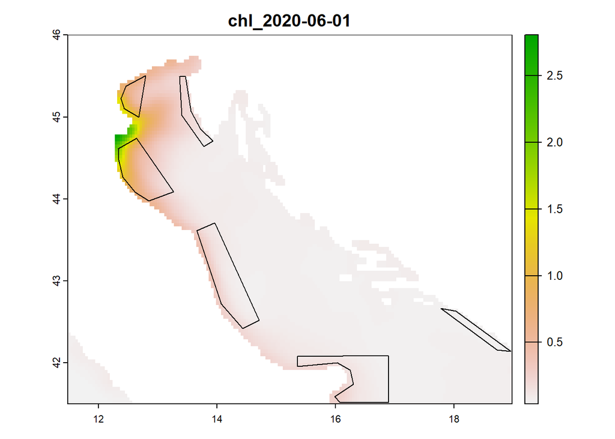

```r
plot(cmems_data,1,main=names(cmems_data)[1])
plot(sample_area,add=TRUE)
```

Extracting the mean values for each area is now simple:

```r
extract(cmems_data,sample_area,fun=mean)
```

```
  ID chl_2020-06-01 chl_2020-07-01 chl_2020-08-01 chl_2020-09-01 so_2020-06-01
1  1      0.6983162     0.51450707     0.40194512     0.39309711      35.80216
2  2      0.1723291     0.16942140     0.13918593     0.14840768      38.00002
3  3      0.0577717     0.04740948     0.05253665     0.06147334      38.23736
4  4      0.1068127     0.09484294     0.09425420     0.10978920      38.16959
5  5      0.6280028     0.44312886     0.28689974     0.44817816      35.77536
6  6      0.1418689     0.13507093     0.13406739     0.16311606      37.60124
  so_2020-07-01 so_2020-08-01 so_2020-09-01 thetao_2020-06-01 thetao_2020-07-01
1      36.62370      36.56990      37.17688          22.37598          25.51120
2      38.37354      37.98575      38.32849          21.75970          24.47568
3      38.62202      38.79627      38.71707          21.46284          24.61978
4      38.54821      38.60776      38.73978          21.59971          25.02958
5      36.23392      37.10024      37.34289          22.21347          25.60168
6      37.65958      38.09582      38.28213          21.75591          25.46740
  thetao_2020-08-01 thetao_2020-09-01
1          26.79764          24.52905
2          25.92913          23.94673
3          26.67230          24.83026
4          26.67653          25.09536
5          26.97072          24.52897
6          26.91947          24.59369
```

By concatenating multiple operations, as we did in the previous section, we can obtain a cleaner table:

```r
cmems_extr_area <- extract(cmems_data,sample_area,fun=mean) %>%
  pivot_longer(cols = -1,names_to = "layer",values_to = "value") %>%
  separate(layer,into = c("var","Date"),sep = "_") %>%
  pivot_wider(id_cols = c(ID,Date),names_from = var,values_from = value)
cmems_extr_area
```

```
# A tibble: 24 × 5
      ID Date          chl    so thetao
   <int> <chr>       <dbl> <dbl>  <dbl>
 1     1 2020-06-01 0.698   35.8   22.4
 2     1 2020-07-01 0.515   36.6   25.5
 3     1 2020-08-01 0.402   36.6   26.8
 4     1 2020-09-01 0.393   37.2   24.5
 5     2 2020-06-01 0.172   38.0   21.8
 6     2 2020-07-01 0.169   38.4   24.5
 7     2 2020-08-01 0.139   38.0   25.9
 8     2 2020-09-01 0.148   38.3   23.9
 9     3 2020-06-01 0.0578  38.2   21.5
10     3 2020-07-01 0.0474  38.6   24.6
# ℹ 14 more rows
```

## Footnotes

[^1]: Note that the first argument of the function `list.files()` is the path of the folder where you saved the data. The path can be expressed as relative to your current working directory (as in the example), or to the root of your computer (e.g., “C:/Users/User/Download/”). To easily get the path to your folder, open it with the file explorer, click on the address bar on the top, select the path and copy-paste it in your code
[^2]: Note that the first argument of `read.csv()` is a string of characters describing the path of the file. As for the `list.files()` function, the path can be written as relative to the working directory or to your computer root (*cfr.* footnote 1).
[^3]: Note that the first argument of the `vect()` function is the path to the `shapefile`. As per the `list.files()` and `read.csv()` functions, the path can be written as relative to the working directory or to your computer root (*cfr.* footnote 1).